# Data Visualization Solutions

Joscelin Rocha Hidalgo

# Load Packages

Let’s load the `tidyverse` package + `ggplot2`.

```r
library(tidyverse)
```

```r
library(ggplot2)
```

# Import chds6162_data

```r
data <- read_csv("data/chds6162_data.csv")
#then run this:
data <- data %>%
  mutate(ded_lbls = case_when(
    ded == 0 ~ "<8th",
    ded == 1 ~ "8th-12th",
    ded == 2 ~ "HS degree",
    ded == 3 ~ "HS+trade",
    ded == 4 ~ "Some college",
    ded == 5 ~ "College degree",
    ded == 6 ~ "Trade school",
    ded == 7 ~ "HS unclear"))
```

# Scatterplot

Make a scatterplot that shows dad weight on the x axis and dad height on the y axis.

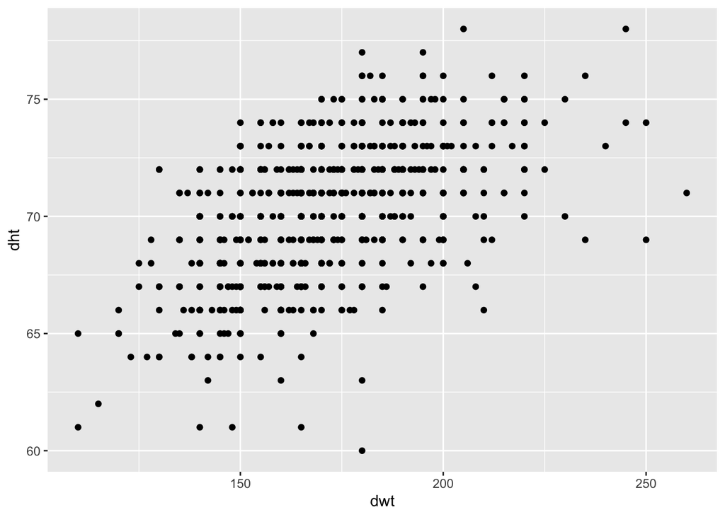

```r
ggplot(data,aes(dwt,dht)) + geom_point()
```

# Histogram

Make a histogram that shows the distribution of the fathers’ weight variable (`dwt`).

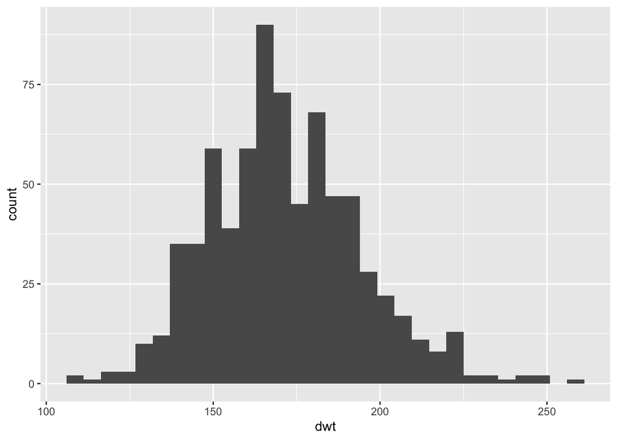

```r
ggplot(data = data,
       mapping = aes(x = dwt)) +
  geom_histogram()
```

Now with try with 50 bins.

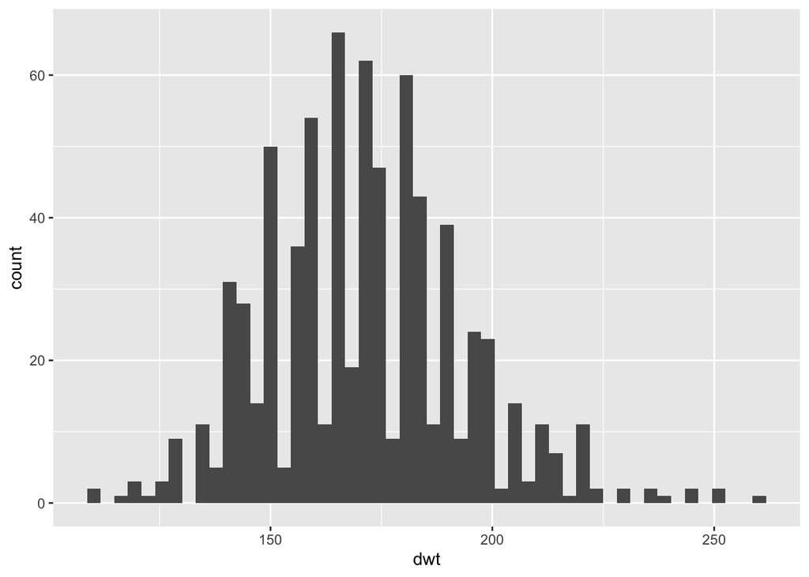

```r
ggplot(data = data,
       mapping = aes(x = dwt)) +
  geom_histogram(bins = 50)
```

# Bar Chart

## Bar Chart for specific values

I created a new dataframe`dad_hgt_by_ed` that shows the average amount of height in inches that males reported based on their education level.

```r
dad_hgt_by_ed <- data %>%
  group_by(ded_lbls) %>%
  summarize(avg_ht = mean(dht, na.rm = TRUE))
```

Plot the average height for fathers for the different education levels (`ded_lbls`). Remember if NAs are being plotted, you can drop them! (hint `drop_NA`)

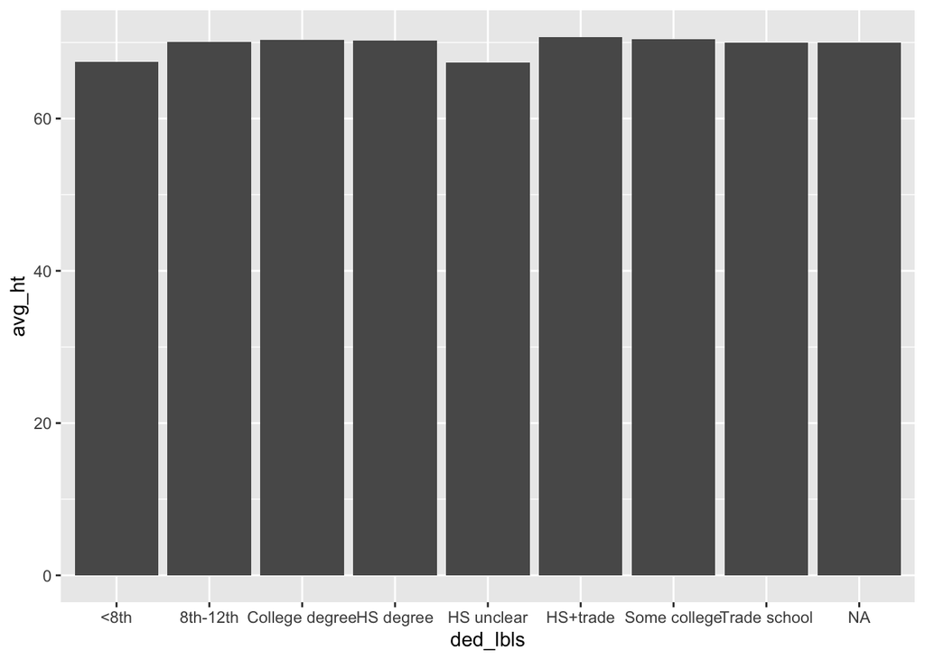

```r
ggplot(data = dad_hgt_by_ed,
       mapping = aes(x = ded_lbls,
                     y = avg_ht)) +
  geom_bar(stat = "identity")
```

# `color` and `fill`

Take your graph from above and make the inside of each bar a different color.

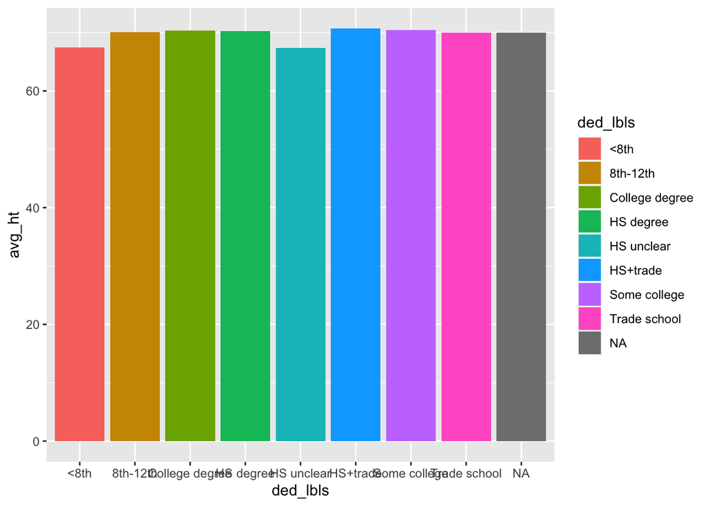

```r
ggplot(data = dad_hgt_by_ed,
       mapping = aes(x = ded_lbls,
                     y = avg_ht,
                     fill = ded_lbls)) +
  geom_bar(stat = "identity")
```

# Scales

## color

Take the scatterplot you made earlier: make the points different colors based on education (`ded`) and add a scale using `scale_color_viridis_d`.

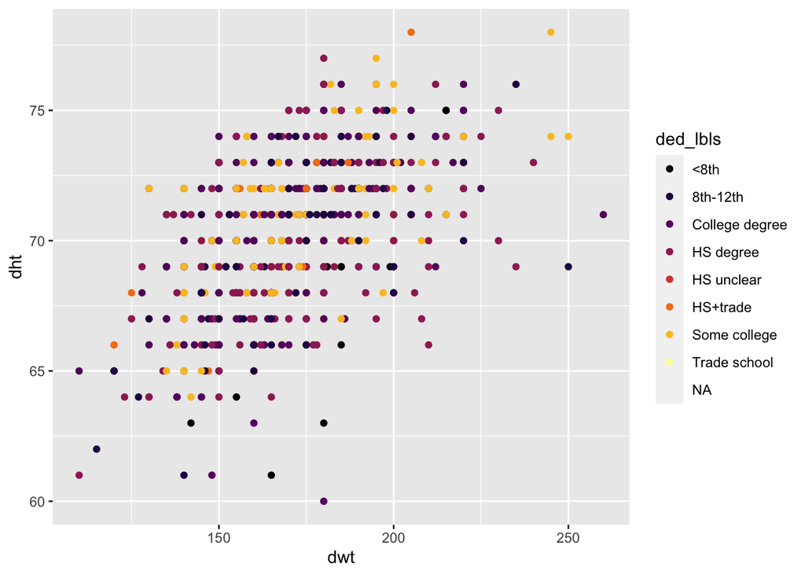

```r
ggplot(data,aes(dwt,dht, color = ded_lbls)) + geom_point() + scale_color_viridis_d(option = "inferno")
```

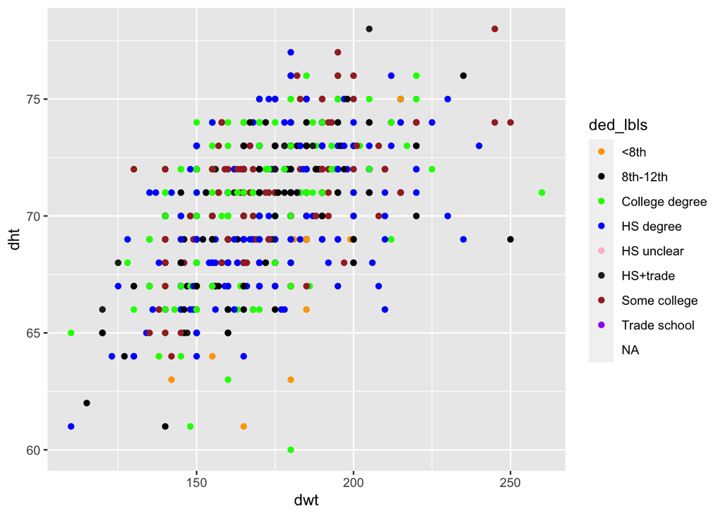

```r
#You can also do it manually:

ggplot(data = data,
       mapping = aes(x = dwt,
                     y = dht,
                     color = ded_lbls)) +
  geom_point() +
  scale_color_manual(values = c("orange", "black","green","blue","pink","#1F271B","brown","purple"))
```

# Plot Labels

Use the code chunk from above and do the following:

1. Add a title
2. Add a better x & y axis label

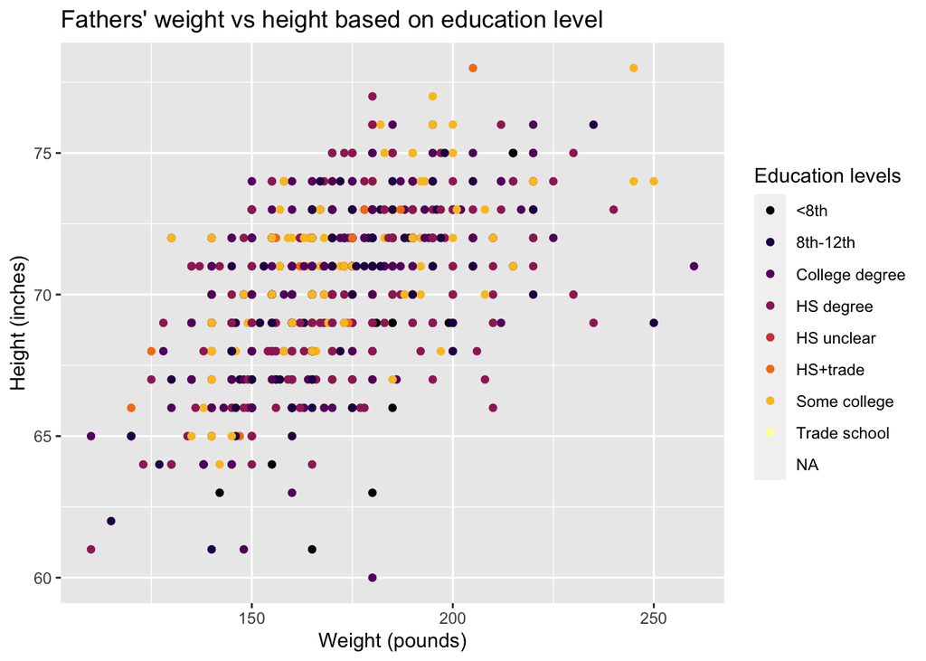

```r
ggplot(data,aes(dwt,dht, color = ded_lbls)) +
  geom_point() +
  scale_color_viridis_d(option = "inferno") +
  labs (title = "Fathers' weight vs height based on education level",
        x = "Weight (pounds)",
        y = "Height (inches)",
        color = "Education levels")
```

# Themes

Use the last plot and add the `theme_classic` to your plot.

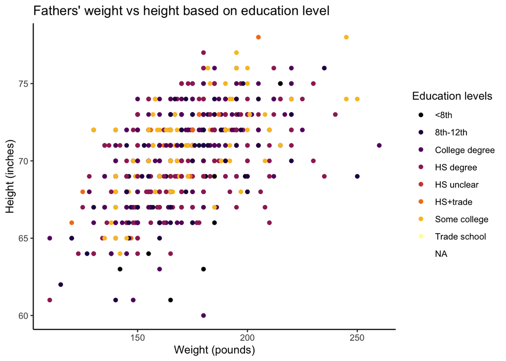

```r
ggplot(data,aes(dwt,dht, color = ded_lbls)) +
  geom_point() + scale_color_viridis_d(option = "inferno") +
  labs (title = "Fathers' weight vs height based on education level",
        x = "Weight (pounds)",
        y = "Height (inches)",
        color = "Education levels") +
  theme_classic()
```

```r
ggsave("plots/my-chunk-plot.png",width = 10, height = 5)
```

# Facets

Instead of looking at the plot the way you did earlier, your boss wants you to create multiple plots (one for each education level). How can you do it? (hint: `facet_wrap(~XX)`)

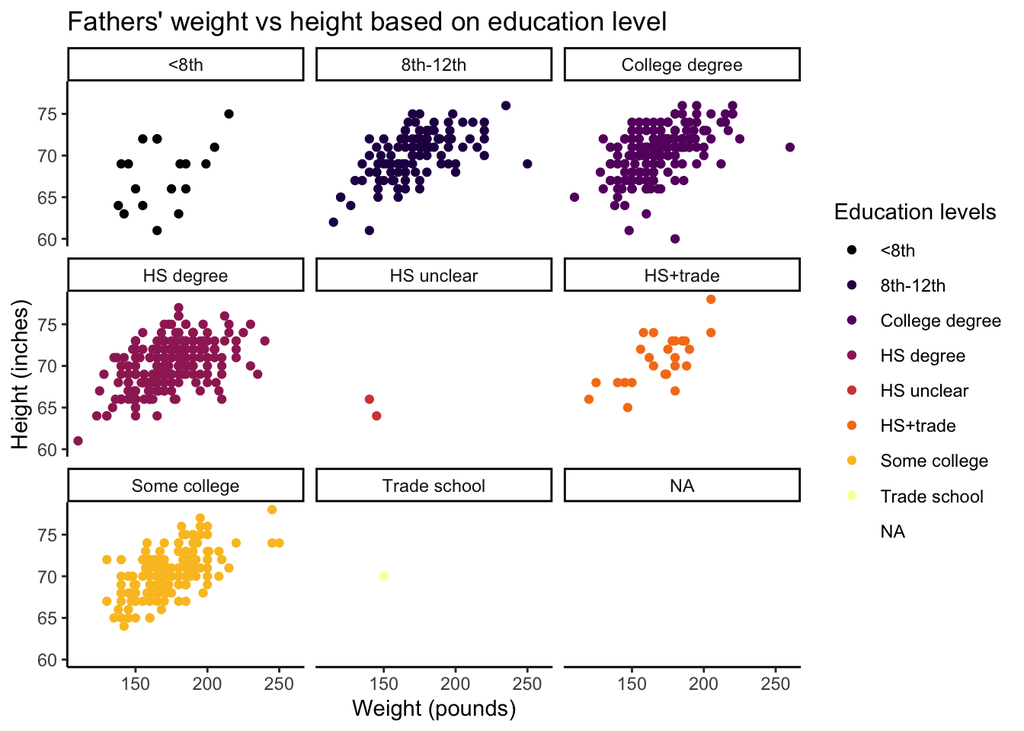

```r
ggplot(data,aes(dwt,dht, color = ded_lbls)) +
  geom_point() +
  scale_color_viridis_d(option = "inferno") +
  labs (title = "Fathers' weight vs height based on education level", x = "Weight (pounds)", y = "Height (inches)", color = "Education levels") +
  theme_classic() +
  facet_wrap(~ded_lbls)
```

# Save Plots

Save your last plot to a PNG that is 10 inches wide and 5 inches high. Put it in the plots directory and call it “my-fav-plot.png”

```r
ggsave("plots/my-fav-plot.png",width = 10, height = 5)
```